# Lab-13: Regression and classification trees

Chu-Chun Ku

# Getting started

In class, we learned how to build a regression tree. In this lab assignment, you will build a classification tree. We will predict a binary outcome, Personal Loan. The loan request is either accepted or it is not.

Start by loading the `tidyverse`, `rpart`, `rpart.plot`, `caret`, and `ggplot2` packages.

```r
library(tidyverse)
library(rpart)
library(rpart.plot)
library(caret)
library(ggplot2)
```

# 1. Data loading and cleaning

Load the dataset `UniversalBank.csv` into a tibble called `bank.df`. Replace all spaces in variable names with a period (‘.’). Drop the `ID` and `ZIP.Code` columns, and inspect the first 6 rows of the dataset. Use `as.factor()` to convert the numeric `Personal.Loan` and `Education` variables into categorical variables.

```r
# Load dataset
library(tidyverse)
library(rpart)
library(rpart.plot)
library(caret)
library(ggplot2)

bank.df <- read.csv("UniversalBank.csv")
head(bank.df)
```

```
##   ID Age Experience Income ZIP.Code Family CCAvg Education Mortgage
## 1  1  25          1     49    91107      4   1.6         1        0
## 2  2  45         19     34    90089      3   1.5         1        0
## 3  3  39         15     11    94720      1   1.0         1        0
## 4  4  35          9    100    94112      1   2.7         2        0
## 5  5  35          8     45    91330      4   1.0         2        0
## 6  6  37         13     29    92121      4   0.4         2      155
##   Personal.Loan Securities.Account CD.Account Online CreditCard
## 1             0                  1          0      0          0
## 2             0                  1          0      0          0
## 3             0                  0          0      0          0
## 4             0                  0          0      0          0
## 5             0                  0          0      0          1
## 6             0                  0          0      1          0
```

```r
names <- names(bank.df)
n_names <- gsub(" ", ".", names)
names(bank.df) <- n_names
names(bank.df)
```

```
##  [1] "ID"                 "Age"                "Experience"
##  [4] "Income"             "ZIP.Code"           "Family"
##  [7] "CCAvg"              "Education"          "Mortgage"
## [10] "Personal.Loan"      "Securities.Account" "CD.Account"
## [13] "Online"             "CreditCard"
```

```r
# drop ID and zip code columns
bank.df <- bank.df %>% select(Age, Experience, Income, Family, CCAvg, Education, Mortgage, Personal.Loan, Securities.Account, CD.Account, Online, CreditCard)

# convert numeric variables to categorical variables
bank.df$Personal.Loan <- as.factor(bank.df$Personal.Loan)
bank.df$Education <- as.factor(bank.df$Education)
str(bank.df)
```

```
## 'data.frame':    5000 obs. of  12 variables:
##  $ Age               : int  25 45 39 35 35 37 53 50 35 34 ...
##  $ Experience        : int  1 19 15 9 8 13 27 24 10 9 ...
##  $ Income            : int  49 34 11 100 45 29 72 22 81 180 ...
##  $ Family            : int  4 3 1 1 4 4 2 1 3 1 ...
##  $ CCAvg             : num  1.6 1.5 1 2.7 1 0.4 1.5 0.3 0.6 8.9 ...
##  $ Education         : Factor w/ 3 levels "1","2","3": 1 1 1 2 2 2 2 3 2 3 ...
##  $ Mortgage          : int  0 0 0 0 0 155 0 0 104 0 ...
##  $ Personal.Loan     : Factor w/ 2 levels "0","1": 1 1 1 1 1 1 1 1 1 2 ...
##  $ Securities.Account: int  1 1 0 0 0 0 0 0 0 0 ...
##  $ CD.Account        : int  0 0 0 0 0 0 0 0 0 0 ...
##  $ Online            : int  0 0 0 0 0 1 1 0 1 0 ...
##  $ CreditCard        : int  0 0 0 0 1 0 0 1 0 0 ...
```

# 2. Build a classification tree

## 2a.

Build a classification tree using `rpart()`, and assign it to an object called `bank.tree`. Because this is a classification tree, we will specify `method="class"` as an argument. In addition, set `cp=0`, and do not limit the depth of the tree. Finally, display the number of leaves in the tree.

```r
# Build the tree
set.seed(1)
bank.tree <- rpart(Personal.Loan ~ .,data = bank.df, cp=0, method="class")

# Number of leaves
n_distinct(bank.tree$where)
```

```
## [1] 15
```

## 2b.

Plot the tree object using the `prp()` command used in class.

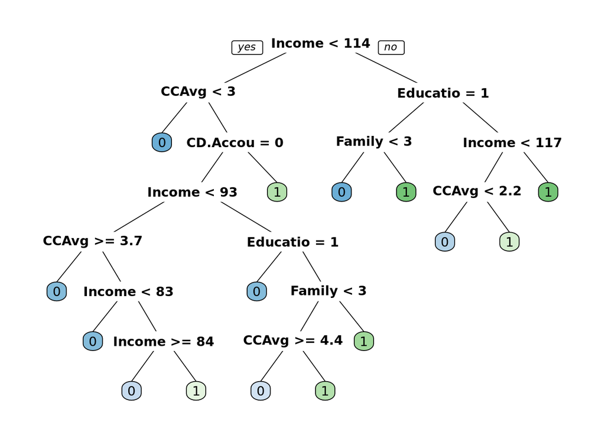

```r
prp(bank.tree, box.palette = "auto")
```

**Question**: What do the numbers below the leaves represent?

## 2c.

Plot the tree object using the `plot()` and `text()` commands. If you are able to create a tree plot that is readable and looks nice, let the professor know!

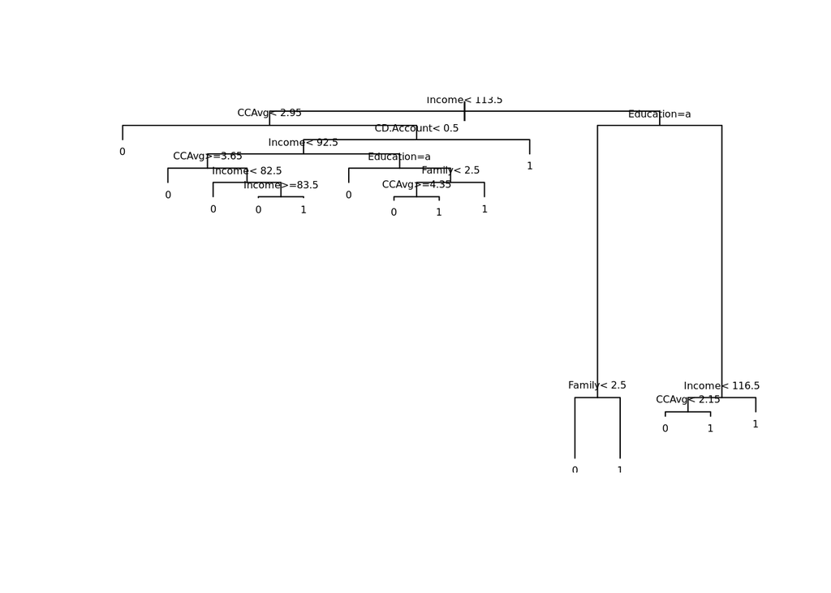

```r
plot(bank.tree)
text(bank.tree, cex = 0.5)
```

# 3. Prune the tree

## 3a.

What is the optimal alpha? What is the cross-validated mean-squared error associated with that alpha?

```r
cp <- printcp(bank.tree)
```

```
##
## Classification tree:
## rpart(formula = Personal.Loan ~ ., data = bank.df, method = "class",
##     cp = 0)
##
## Variables actually used in tree construction:
## [1] CCAvg      CD.Account Education  Family     Income
##
## Root node error: 480/5000 = 0.096
##
## n= 5000
##
##           CP nsplit rel error  xerror     xstd
## 1 0.32291667      0   1.00000 1.00000 0.043397
## 2 0.14375000      2   0.35417 0.35625 0.026773
## 3 0.01458333      3   0.21042 0.21458 0.020925
## 4 0.00937500      7   0.14792 0.14792 0.017429
## 5 0.00416667      9   0.12917 0.13542 0.016687
## 6 0.00069444     11   0.12083 0.15417 0.017788
## 7 0.00000000     14   0.11875 0.16458 0.018370
```

```r
# Minimum CV MSE
cvmse.min <- min(cp[ , "xerror"])
print(paste("Min CV MSE is", cvmse.min))
```

```
## [1] "Min CV MSE is 0.135416666666667"
```

```r
# Optimal alpha
index <- which.min(cp[ , "xerror"])
alpha.best <- cp[index,"CP"]
print(paste("Optimal alpha is", alpha.best))
```

```
## [1] "Optimal alpha is 0.00416666666666667"
```

## 3b.

Use the optimal alpha to prune the tree. Create a plot of the pruned tree using `prp`, and calculate how many leaves the plot has.

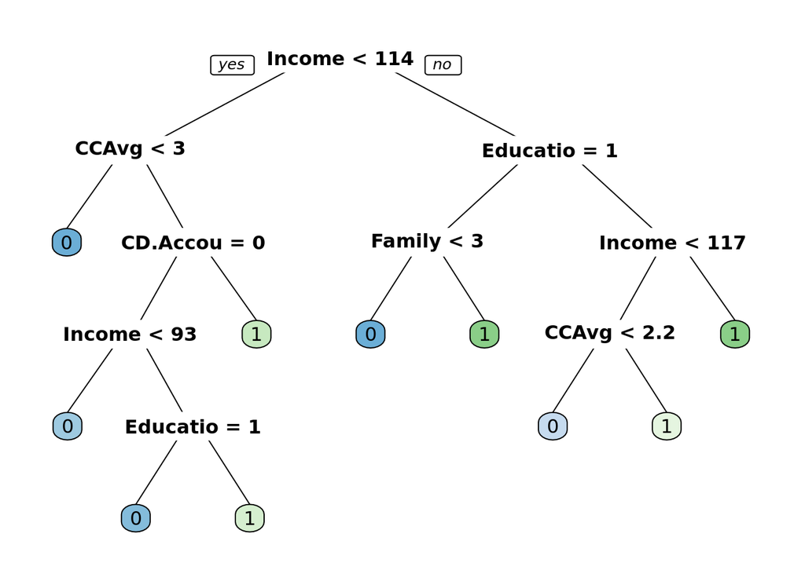

```r
# Prune tree
prune_tree <- prune(bank.tree, cp = alpha.best)

# Pruned tree plot
prp(prune_tree, box.palette = "auto")
```

```r
# Number of leaves
n_distinct(prune_tree$where)
```

```
## [1] 10
```

# 4. Make predictions and compare to logistic regression

## 4a.

Use the pruned tree to predict the outcome variable, `Personal.Loan`. Use the `predict()` function, and specify `type="class"`. Confirm that the number of predictions matches the number of observations in the dataset.

```r
# Prediction
predict <- predict(prune_tree, newdata = bank.df, type="class")
length(predict)
```

```
## [1] 5000
```

```r
nrow(bank.df)
```

```
## [1] 5000
```

## 4b.

Using the function `confusionMatrix()`, create a confusion matrix to assess the quality of the tree predictions. Store it in an object, `cm.tree`, and display it.

```r
# Confusion Matrix
cm.tree <- confusionMatrix(predict, bank.df$Personal.Loan)
cm.tree
```

```
## Confusion Matrix and Statistics
##
##           Reference
## Prediction    0    1
##          0 4495   37
##          1   25  443
##
##                Accuracy : 0.9876
##                  95% CI : (0.9841, 0.9905)
##     No Information Rate : 0.904
##     P-Value [Acc > NIR] : <2e-16
##
##                   Kappa : 0.9278
##
##  Mcnemar's Test P-Value : 0.1624
##
##             Sensitivity : 0.9945
##             Specificity : 0.9229
##          Pos Pred Value : 0.9918
##          Neg Pred Value : 0.9466
##              Prevalence : 0.9040
##          Detection Rate : 0.8990
##    Detection Prevalence : 0.9064
##       Balanced Accuracy : 0.9587
##
##        'Positive' Class : 0
##
```

## 4b.

Use `glm()` to estimate a logistic regression of `Personal.Loan` on the other variables in the `bank.df` dataset. Store the vector of predicted probabilities in `yhat.logit.prob`. Store the vector of predicted classifications (0/1) in `yhat.logit`.

```r
# Logistic regression
logit <- glm(Personal.Loan ~ ., data = bank.df, family = "binomial")

# Logistic predictions
yhat.logit.prob <- predict(logit, bank.df, type = "response")
yhat.logit <- as.factor(ifelse(yhat.logit.prob > 0.5, 1, 0))
```

## 4c.

Create a confusion matrix to assess the quality of the logit predictions. Store it in an object, `cm.logit`, and display it.

```r
# Logit confusion matrix
cm.logit <- confusionMatrix(yhat.logit, bank.df$Personal.Loan)
cm.logit
```

```
## Confusion Matrix and Statistics
##
##           Reference
## Prediction    0    1
##          0 4471  156
##          1   49  324
##
##                Accuracy : 0.959
##                  95% CI : (0.9531, 0.9643)
##     No Information Rate : 0.904
##     P-Value [Acc > NIR] : < 2.2e-16
##
##                   Kappa : 0.7376
##
##  Mcnemar's Test P-Value : 1.328e-13
##
##             Sensitivity : 0.9892
##             Specificity : 0.6750
##          Pos Pred Value : 0.9663
##          Neg Pred Value : 0.8686
##              Prevalence : 0.9040
##          Detection Rate : 0.8942
##    Detection Prevalence : 0.9254
##       Balanced Accuracy : 0.8321
##
##        'Positive' Class : 0
##
```

**Question**: Use the output of the confusion matrices to evaluate which model (classification tree or logit) does a better job at prediction in this setting. Your answer should include a discussion of false positives and false negatives.

**Answer**: From the output of confusion matrices, the classification tree does a better job, and we can see the points from the following comparison: (1.) Accuracy: classification tree’s accuracy 0.9876 is higher than logit’s 0.959. (2.) The false positives value: classification tree’s 37 is lower than logit’s 156. (3.) The false negatives value: classification tree’s 25 is lower than logit’s 49.